# Assignment 2 - Logistic Regression

ITAO 40420 - Machine Learning

29 January 2021

```r
library(ggplot2) # load ggplot
library(reshape) # load reshape 2
library(glmnet) # Load glmnet
library(plotmo) # for plot_glmnet
```

# Assignment 2

For this analysis we will be using churn data. The dataset is stored as `churn_data.rda` which can be loaded in by running the below command if the file is located in your working directory or else by accessing the file through file->open file

```r
load("churn_data.rda") # Load churn dataset
```

We can view a summary of this dataset by running `summary()`:

```r
summary(churn_data)
```

```
##     gender          SeniorCitizen      Partner           Dependents
##  Length:7032        Min.   :0.0000   Length:7032        Length:7032
##  Class :character   1st Qu.:0.0000   Class :character   Class :character
##  Mode  :character   Median :0.0000   Mode  :character   Mode  :character
##                     Mean   :0.1624
##                     3rd Qu.:0.0000
##                     Max.   :1.0000
##      tenure      PhoneService       MultipleLines      InternetService
##  Min.   : 1.00   Length:7032        Length:7032        Length:7032
##  1st Qu.: 9.00   Class :character   Class :character   Class :character
##  Median :29.00   Mode  :character   Mode  :character   Mode  :character
##  Mean   :32.42
##  3rd Qu.:55.00
##  Max.   :72.00
##  OnlineSecurity     OnlineBackup       DeviceProtection   TechSupport
##  Length:7032        Length:7032        Length:7032        Length:7032
##  Class :character   Class :character   Class :character   Class :character
##  Mode  :character   Mode  :character   Mode  :character   Mode  :character
##
##
##
##  StreamingTV        StreamingMovies      Contract         PaperlessBilling
##  Length:7032        Length:7032        Length:7032        Length:7032
##  Class :character   Class :character   Class :character   Class :character
##  Mode  :character   Mode  :character   Mode  :character   Mode  :character
##
##
##
##  PaymentMethod      MonthlyCharges    TotalCharges        Churn
##  Length:7032        Min.   : 18.25   Min.   :  18.8   Min.   :0.0000
##  Class :character   1st Qu.: 35.59   1st Qu.: 401.4   1st Qu.:0.0000
##  Mode  :character   Median : 70.35   Median :1397.5   Median :0.0000
##                     Mean   : 64.80   Mean   :2283.3   Mean   :0.2658
##                     3rd Qu.: 89.86   3rd Qu.:3794.7   3rd Qu.:1.0000
##                     Max.   :118.75   Max.   :8684.8   Max.   :1.0000
```

The variables we have are:

- Gender - Whether the customer is a male or a female
- SeniorCitizen - Whether the customer is a senior citizen or not (1,0)
- Partner - Whether the customer has a partner or nor (Yes, No)
- Dependents - Whether the customer has dependents or not (Yes, No)
- tenure - Number of months the customer has stayed with the company
- PhoneService - Whether the customer has a phone service of no (Yes, No)
- MultipleLines - Whether the customer has multiple lines or not (Yes, No, No phone service)
- InternetService - Customer’s internet service provider (DSL, Fiber optic, No)
- OnlineSecurity - Whether the customer has online security or not (Yes, No, No internet service)
- OnlineBackup - Whether the customer has online backup or not (Yes, No, No internet service)
- DeviceProtection - Whether the customer has tech support or not (Yes, No, No internet service)
- StreamingTV - Whether the customer has streaming TV or not (Yes, No, No internet service)
- StreamingMovies - Whether the customer has streaming movies or not (Yes, No, No internet service)
- Contract - The contract term of the customer (Month-to-month, One year, Two year)
- PaperlessBilling - Whether the customer has paperless billing or not (Yes, No)
- PaymentMethod - The customer’s payment method (Electronic CHECK, Mailed check, Bank transfer (automatic), Credit card (automatic))
- MonthlyCharges - The amount charged to the customer monthly
- TotalCharges - The total amount charged to the customer
- Churn - Whether the customer churned or not (1 = Yes or 0 = No)

The response variable for this dataset is `Churn`:

```r
summary(as.factor(churn_data$Churn))
```

```
##    0    1
## 5163 1869
```

```r
plot_data <- churn_data
plot_data$Churn <- as.factor(plot_data$Churn)
```

For the assignment please carry out the following tasks/answer the following questions: (12 Points)

- 1 - Create at least two visualizations potentially revealing factors with predictive power (2 Points)

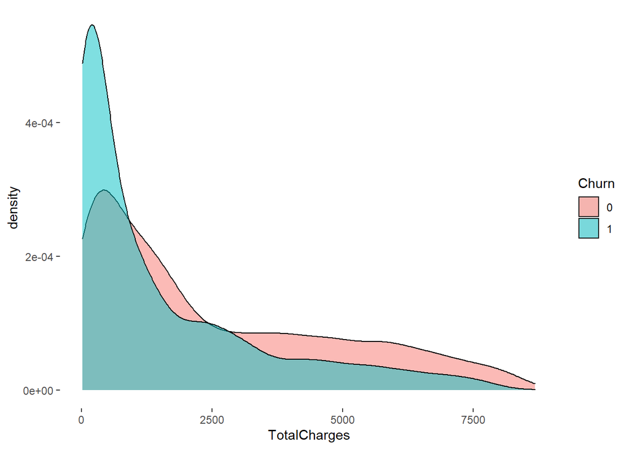

```r
g_1 <- ggplot(plot_data, aes(x = TotalCharges, fill = Churn)) +
  geom_density(alpha = 0.5) + # Select density plot and set transperancy (alpha)
    theme_set(theme_bw(base_size = 22) ) + # Set theme and text size
  theme(panel.grid.major = element_blank(), # Remove grid
        panel.grid.minor = element_blank(), # Remove grid
        panel.border = element_blank(), # Remove grid
        panel.background = element_blank())
g_1
```

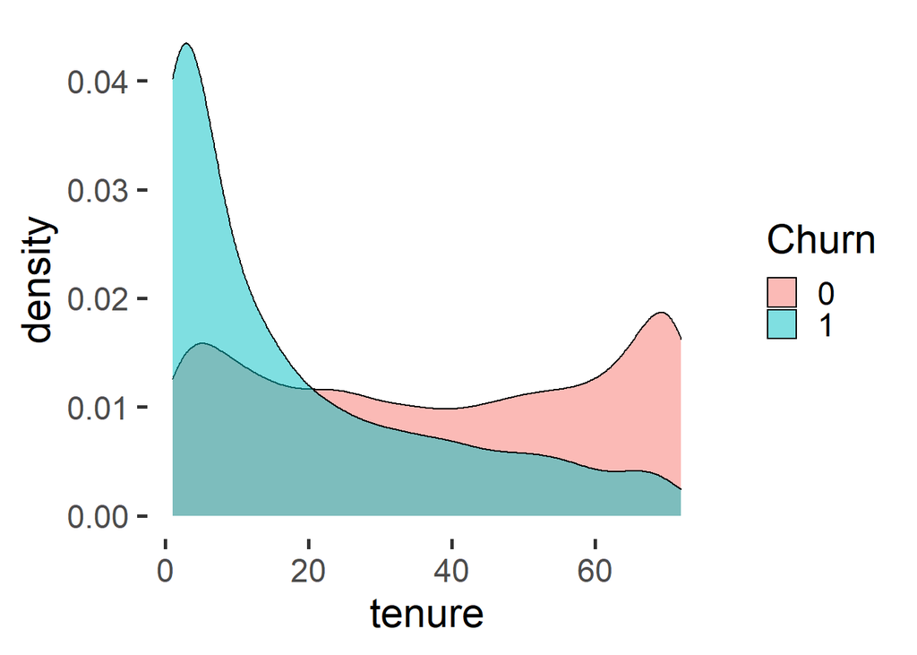

```r
g_2 <- ggplot(plot_data, aes(x = tenure, fill = Churn)) + # Set x as mean radius and fill as diagnosis
  geom_density(alpha = 0.5) + # Select density plot and set transperancy (alpha)
    theme_set(theme_bw(base_size = 22) ) + # Set theme and text size
  theme(panel.grid.major = element_blank(), # Remove grid
        panel.grid.minor = element_blank(), # Remove grid
        panel.border = element_blank(), # Remove grid
        panel.background = element_blank())
g_2
```

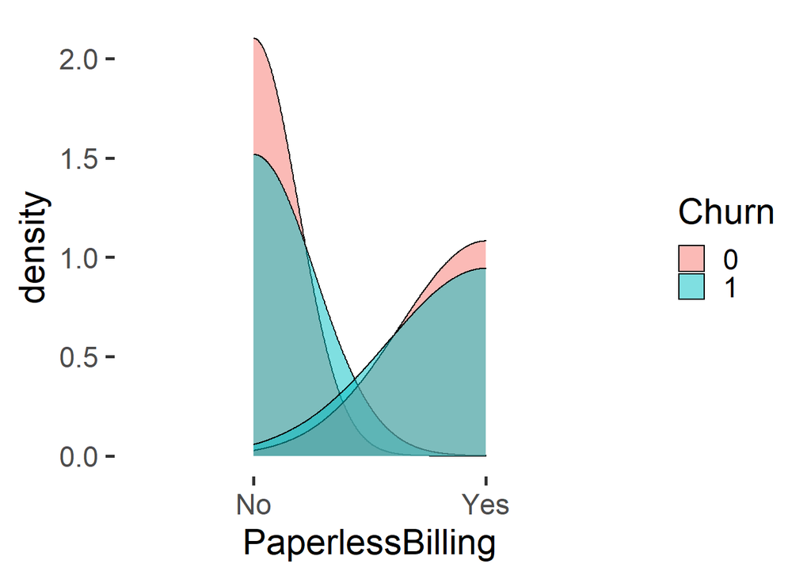

```r
g_3 <- ggplot(plot_data, aes(x = PaperlessBilling, fill = Churn)) +
  geom_density(alpha = 0.5) + # Select density plot and set transperancy (alpha)
    theme_set(theme_bw(base_size = 22) ) + # Set theme and text size
  theme(panel.grid.major = element_blank(), # Remove grid
        panel.grid.minor = element_blank(), # Remove grid
        panel.border = element_blank(), # Remove grid
        panel.background = element_blank())
g_3
```

- 2 - Fit a logistic regression model to the data. (Remember you can use `resp ~.,` to include all explanatory variables in the model) (2 Points)

```r
fit_full <- glm(Churn ~ .,
             family=binomial(link='logit'),
             data= churn_data)
summary(fit_full)
```

```
##
## Call:
## glm(formula = Churn ~ ., family = binomial(link = "logit"), data = churn_data)
##
## Deviance Residuals:
##     Min       1Q   Median       3Q      Max
## -1.9180  -0.6791  -0.2855   0.7282   3.4300
##
## Coefficients: (7 not defined because of singularities)
##                                        Estimate Std. Error z value Pr(>|z|)
## (Intercept)                           1.165e+00  8.151e-01   1.430  0.15284
## genderMale                           -2.183e-02  6.480e-02  -0.337  0.73619
## SeniorCitizen                         2.168e-01  8.453e-02   2.564  0.01033 *
## PartnerYes                           -3.840e-04  7.783e-02  -0.005  0.99606
## DependentsYes                        -1.485e-01  8.973e-02  -1.655  0.09796 .
## tenure                               -6.059e-02  6.236e-03  -9.716  < 2e-16 ***
## PhoneServiceYes                       1.715e-01  6.487e-01   0.264  0.79153
## MultipleLinesNo phone service                NA         NA      NA       NA
## MultipleLinesYes                      4.484e-01  1.773e-01   2.530  0.01142 *
## InternetServiceFiber optic            1.747e+00  7.981e-01   2.190  0.02855 *
## InternetServiceNo                    -1.786e+00  8.073e-01  -2.213  0.02691 *
## OnlineSecurityNo internet service            NA         NA      NA       NA
## OnlineSecurityYes                    -2.054e-01  1.787e-01  -1.150  0.25031
## OnlineBackupNo internet service              NA         NA      NA       NA
## OnlineBackupYes                       2.604e-02  1.754e-01   0.148  0.88197
## DeviceProtectionNo internet service          NA         NA      NA       NA
## DeviceProtectionYes                   1.474e-01  1.764e-01   0.836  0.40339
## TechSupportNo internet service               NA         NA      NA       NA
## TechSupportYes                       -1.805e-01  1.806e-01  -0.999  0.31759
## StreamingTVNo internet service               NA         NA      NA       NA
## StreamingTVYes                        5.905e-01  3.263e-01   1.810  0.07035 .
## StreamingMoviesNo internet service           NA         NA      NA       NA
## StreamingMoviesYes                    5.993e-01  3.267e-01   1.834  0.06658 .
## ContractOne year                     -6.608e-01  1.076e-01  -6.142 8.15e-10 ***
## ContractTwo year                     -1.357e+00  1.764e-01  -7.691 1.46e-14 ***
## PaperlessBillingYes                   3.424e-01  7.450e-02   4.596 4.31e-06 ***
## PaymentMethodCredit card (automatic) -8.779e-02  1.141e-01  -0.770  0.44156
## PaymentMethodElectronic check         3.045e-01  9.450e-02   3.222  0.00127 **
## PaymentMethodMailed check            -5.759e-02  1.149e-01  -0.501  0.61627
## MonthlyCharges                       -4.034e-02  3.176e-02  -1.270  0.20392
## TotalCharges                          3.289e-04  7.063e-05   4.657 3.20e-06 ***
## ---
## Signif. codes:  0 '***' 0.001 '**' 0.01 '*' 0.05 '.' 0.1 ' ' 1
##
## (Dispersion parameter for binomial family taken to be 1)
##
##     Null deviance: 8143.4  on 7031  degrees of freedom
## Residual deviance: 5826.3  on 7008  degrees of freedom
## AIC: 5874.3
##
## Number of Fisher Scoring iterations: 6
```

```r
fit_model <- glm(Churn ~
               SeniorCitizen
             + tenure
             + Contract
             + PaperlessBilling
             + PaymentMethod
             + MonthlyCharges
             + TotalCharges,
            family = binomial(link='logit'),
             data= churn_data)
summary(fit_model)
```

```
##
## Call:
## glm(formula = Churn ~ SeniorCitizen + tenure + Contract + PaperlessBilling +
##     PaymentMethod + MonthlyCharges + TotalCharges, family = binomial(link = "logit"),
##     data = churn_data)
##
## Deviance Residuals:
##     Min       1Q   Median       3Q      Max
## -1.8433  -0.7167  -0.3023   0.7689   3.4626
##
## Coefficients:
##                                        Estimate Std. Error z value Pr(>|z|)
## (Intercept)                          -1.395e+00  1.560e-01  -8.945  < 2e-16 ***
## SeniorCitizen                         3.752e-01  8.116e-02   4.622 3.79e-06 ***
## tenure                               -5.673e-02  6.030e-03  -9.407  < 2e-16 ***
## ContractOne year                     -8.760e-01  1.034e-01  -8.475  < 2e-16 ***
## ContractTwo year                     -1.733e+00  1.715e-01 -10.103  < 2e-16 ***
## PaperlessBillingYes                   4.368e-01  7.257e-02   6.019 1.75e-09 ***
## PaymentMethodCredit card (automatic) -8.674e-02  1.122e-01  -0.773 0.439396
## PaymentMethodElectronic check         4.315e-01  9.246e-02   4.667 3.05e-06 ***
## PaymentMethodMailed check            -1.376e-01  1.119e-01  -1.230 0.218725
## MonthlyCharges                        1.772e-02  1.922e-03   9.219  < 2e-16 ***
## TotalCharges                          2.523e-04  6.745e-05   3.741 0.000183 ***
## ---
## Signif. codes:  0 '***' 0.001 '**' 0.01 '*' 0.05 '.' 0.1 ' ' 1
##
## (Dispersion parameter for binomial family taken to be 1)
##
##     Null deviance: 8143.4  on 7031  degrees of freedom
## Residual deviance: 5998.0  on 7021  degrees of freedom
## AIC: 6020
##
## Number of Fisher Scoring iterations: 6
```

- 3 - What features are significant in your logistic regression model? (1 Point)

Significant predictors =  
SeniorCitizen, tenure, ContractOne year, ContractTwo year, PaperlessBillingYes, PaymentMethodElectronic check , MonthlyCharges, TotalCharges

- 4 - What is the AIC of your logistic regression model? (1 Point)

full model AIC = 5874.3 reduced variable AIC: 6020

- 5 - Add an interaction term to the logistic regression model? (1 Point)

```r
fit_model <- glm(Churn ~ .
             + (tenure * MonthlyCharges),
            family = binomial(link='logit'),
             data= churn_data)
summary(fit_model)
```

```
##
## Call:
## glm(formula = Churn ~ . + (tenure * MonthlyCharges), family = binomial(link = "logit"),
##     data = churn_data)
##
## Deviance Residuals:
##     Min       1Q   Median       3Q      Max
## -1.9186  -0.6792  -0.2855   0.7282   3.4298
##
## Coefficients: (7 not defined because of singularities)
##                                        Estimate Std. Error z value Pr(>|z|)
## (Intercept)                           1.165e+00  8.153e-01   1.429  0.15312
## genderMale                           -2.182e-02  6.481e-02  -0.337  0.73633
## SeniorCitizen                         2.168e-01  8.455e-02   2.565  0.01032 *
## PartnerYes                           -3.991e-04  7.783e-02  -0.005  0.99591
## DependentsYes                        -1.485e-01  8.973e-02  -1.655  0.09802 .
## tenure                               -6.055e-02  6.301e-03  -9.609  < 2e-16 ***
## PhoneServiceYes                       1.715e-01  6.487e-01   0.264  0.79152
## MultipleLinesNo phone service                NA         NA      NA       NA
## MultipleLinesYes                      4.485e-01  1.773e-01   2.530  0.01141 *
## InternetServiceFiber optic            1.748e+00  7.981e-01   2.190  0.02855 *
## InternetServiceNo                    -1.786e+00  8.073e-01  -2.213  0.02693 *
## OnlineSecurityNo internet service            NA         NA      NA       NA
## OnlineSecurityYes                    -2.054e-01  1.787e-01  -1.149  0.25039
## OnlineBackupNo internet service              NA         NA      NA       NA
## OnlineBackupYes                       2.614e-02  1.754e-01   0.149  0.88152
## DeviceProtectionNo internet service          NA         NA      NA       NA
## DeviceProtectionYes                   1.473e-01  1.764e-01   0.835  0.40365
## TechSupportNo internet service               NA         NA      NA       NA
## TechSupportYes                       -1.805e-01  1.806e-01  -0.999  0.31762
## StreamingTVNo internet service               NA         NA      NA       NA
## StreamingTVYes                        5.906e-01  3.263e-01   1.810  0.07032 .
## StreamingMoviesNo internet service           NA         NA      NA       NA
## StreamingMoviesYes                    5.993e-01  3.267e-01   1.834  0.06658 .
## ContractOne year                     -6.609e-01  1.076e-01  -6.142 8.15e-10 ***
## ContractTwo year                     -1.357e+00  1.765e-01  -7.690 1.47e-14 ***
## PaperlessBillingYes                   3.424e-01  7.450e-02   4.596 4.31e-06 ***
## PaymentMethodCredit card (automatic) -8.783e-02  1.141e-01  -0.770  0.44138
## PaymentMethodElectronic check         3.044e-01  9.451e-02   3.221  0.00128 **
## PaymentMethodMailed check            -5.756e-02  1.149e-01  -0.501  0.61644
## MonthlyCharges                       -4.034e-02  3.176e-02  -1.270  0.20402
## TotalCharges                          3.509e-04  5.278e-04   0.665  0.50615
## tenure:MonthlyCharges                -2.245e-05  5.348e-04  -0.042  0.96652
## ---
## Signif. codes:  0 '***' 0.001 '**' 0.01 '*' 0.05 '.' 0.1 ' ' 1
##
## (Dispersion parameter for binomial family taken to be 1)
##
##     Null deviance: 8143.4  on 7031  degrees of freedom
## Residual deviance: 5826.3  on 7007  degrees of freedom
## AIC: 5876.3
##
## Number of Fisher Scoring iterations: 6
```

- 6 - Does the addition of the interaction term increase or decrease the AIC? What is the new AIC for the model? (1 Point)

Addition of interaction term has increased the AIC.  
AIC went up from 5874.3 to 5876.3.

- 7 - Fit a lasso logistic regression model to the data. (1 Point)

```r
library(glmnet)
names(churn_data)
```

```
##  [1] "gender"           "SeniorCitizen"    "Partner"          "Dependents"
##  [5] "tenure"           "PhoneService"     "MultipleLines"    "InternetService"
##  [9] "OnlineSecurity"   "OnlineBackup"     "DeviceProtection" "TechSupport"
## [13] "StreamingTV"      "StreamingMovies"  "Contract"         "PaperlessBilling"
## [17] "PaymentMethod"    "MonthlyCharges"   "TotalCharges"     "Churn"
```

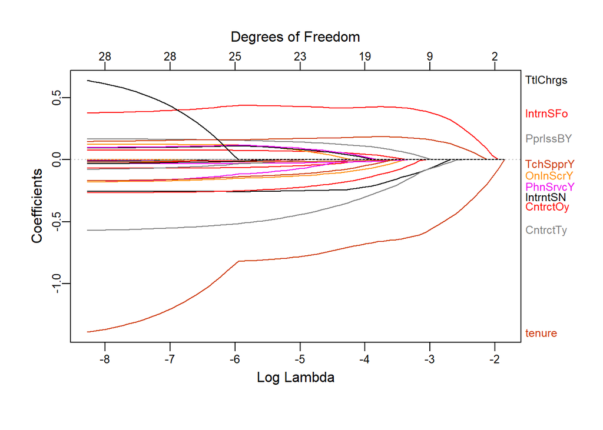

```r
x_vars <- model.matrix(Churn ~.,
                       churn_data)[,-1]

x_data <- as.data.frame(scale(x_vars)) # Scale dataset

lasso_fit <- glmnet(x = x_data, # Set explantory variables
                    y = churn_data$Churn, # Set response variable
                    alpha = 1, # Set alpha value
                    family = "binomial")

plot_glmnet(lasso_fit, # Plot lasso coefficients by lambda
            xvar = "lambda")
```

- 8 - Which coefficients were non-zero in the lasso model? Were they positive or negative? What does this imply? (1 Point)

```r
lasso_fit_1 <- glmnet(x = x_data, # Set explantory variables
                    y = churn_data$Churn, # Set response variable
                    alpha = 1, # Set alpha value
                    family = "binomial",
                    lambda = 0.05) #Set lambda to 0.05 to get set values of coefficients

coef(lasso_fit_1)
```

```
## 31 x 1 sparse Matrix of class "dgCMatrix"
##                                                 s0
## (Intercept)                          -1.163032e+00
## genderMale                            .
## SeniorCitizen                         .
## PartnerYes                            .
## DependentsYes                         .
## tenure                               -5.634926e-01
## PhoneServiceYes                       .
## MultipleLinesNo phone service         .
## MultipleLinesYes                      .
## InternetServiceFiber optic            3.807399e-01
## InternetServiceNo                    -7.014256e-02
## OnlineSecurityNo internet service    -6.629804e-15
## OnlineSecurityYes                     .
## OnlineBackupNo internet service      -4.769643e-16
## OnlineBackupYes                       .
## DeviceProtectionNo internet service  -1.067711e-05
## DeviceProtectionYes                   .
## TechSupportNo internet service       -3.004875e-15
## TechSupportYes                        .
## StreamingTVNo internet service        .
## StreamingTVYes                        .
## StreamingMoviesNo internet service   -1.907857e-16
## StreamingMoviesYes                    .
## ContractOne year                      .
## ContractTwo year                     -7.089902e-02
## PaperlessBillingYes                   4.637907e-03
## PaymentMethodCredit card (automatic)  .
## PaymentMethodElectronic check         1.617111e-01
## PaymentMethodMailed check             .
## MonthlyCharges                        .
## TotalCharges                          .
```

There are a total of 11 non-zero coefficients. 8 of the coefficients are negative and 3 are positive. This implies that higher values for the positive variables and lower values for the negative negative, both lead to higher churn probability.

2 Points for analysis decisions and code quality.

Please submit an an R-markdown document with the answers, optionally you can submit an R-script with the code used for your analysis and a document answering the specific questions, you can use word, pdf etc.

Assignments can be submitted via Canvas or by email to mbarron2@nd.edu.